# Defensible Spaces - Leiria

Omar Nooreddin

08/07/2019

# Introduction

This paper endeavours to identify Defensible Spaces (DS) by use of satellite imagery and areas marked for cleaning by municipalities (using KML files) coupled with use of Vegetation Indicies. Different indicies will be employed in order to decide which index will be the most suitable in identifying a DS. The premis of this assumption, is that DS will be cleared from vegetation, therefore there will be a starck contrast between the DS and the neighbouring areas. In order to carry out our analysis we’re going to load a few packages to aid in the analysis:

```r
#Required to read KML file
require(rgdal)

#Required for CRS conversion
require(sf)

#Required for converting JP2 to tiff
require(gdalUtils)

#Required for reading tiffs
require(raster)
```

# Acquiring Satellite Images (and KML file)

The images used for the analysis can be found [here](https://images.app.goo.gl/uqpSY1gysmouir4v6) along with KML file used.

#### Landsat7 ETM+ Images

# Identifying the Area

An area was provided where a DS needs to be cleared in Leiria. We’ll go ahead and load the KML file (which was originally a KMZ file that has been renamed to “.zip” and unzipped):

```r
ds<-readOGR("doc.kml")
crs(ds)
```

```
## CRS arguments:
##  +proj=longlat +datum=WGS84 +no_defs +ellps=WGS84 +towgs84=0,0,0
```

We can see that the projection of the KML file is long/lat, which is different from the Sentinel & Landsat images, which we’re going to use later. As such we’ll convert the projection.

# Converting and Loading Sentinel Images

```r
#convert bands 8 and 4 into tiff
#Band 4
gdal_translate("S2B_MSIL1C_20190622T113329_N0207_R080_T29TNE_20190622T123903.SAFE/GRANULE/L1C_T29TNE_A011975_20190622T113327/IMG_DATA/T29TNE_20190622T113329_B04.jp2","B04sen.tif")
```

```r
#Band8
gdal_translate("S2B_MSIL1C_20190622T113329_N0207_R080_T29TNE_20190622T123903.SAFE/GRANULE/L1C_T29TNE_A011975_20190622T113327/IMG_DATA/T29TNE_20190622T113329_B08.jp2","B08sen.tif")
```

# Reading the tiffs - Sentinel

Here we’ll set out to read the tiffs into R as a Raster object:

```r
#Band 4 - Sentinel 2
band4sen<-raster("B04sen.tif")

#Band 8 - Sentinel
band8sen<-raster("B08sen.tif")

crs(band8sen)
```

```
## CRS arguments:
##  +proj=utm +zone=29 +datum=WGS84 +units=m +no_defs +ellps=WGS84
## +towgs84=0,0,0
```

From the above, we can see that the projection of the tiffs is in UTM, therefore we’ll convert the KML into UTM

# Converting KML

As per above, we’ll convert the Coordinate Reference System (CRS) of the KML into the same projection as the tiffs from sentinel:

```r
ds<-spTransform(ds, crs(band8sen))
crs(ds)
```

```
## CRS arguments:
##  +proj=utm +zone=29 +datum=WGS84 +units=m +no_defs +ellps=WGS84
## +towgs84=0,0,0
```

Now the CRS of KML is the same as the tiff

# Cropping Sentinel Images

Since we only require the portion of the image as far as the extent of the KML file, we’re going to crop the images into a smaller size to speed up our processing:

```r
#Crop band4 image
band4sen<-crop(band4sen, extent(ds))

#Crop band8 image
band8sen<-crop(band8sen, extent(ds))
```

# Plot Cropped Images

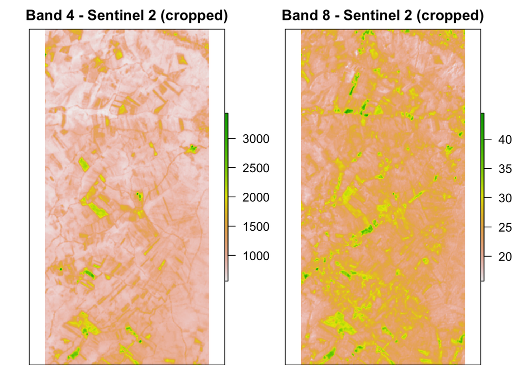

```r
#Set margins to zero to utilise maximum space
par(mar=c(0,2,2,0), mfrow=c(1,2))

#Now plot band 4 and 8
plot(band4sen, main="Band 4 - Sentinel 2 (cropped)", axes=FALSE)
plot(band8sen, main="Band 8 - Sentinel 2 (cropped)", axes=FALSE)
```

# Analysis

### Visual Analysis

In order to analyse the area provided, we’re going to do the following:

1. Apply an Index of our choice (NDVI, SAVI, etc…)
2. Plot the resultant image
3. Remove pixels below - or above, depending on index in use - a certain value in order to remove parts of the image where it’s showing high vegetation and we’re left only with with “bare soil” areas (i.e cleaned areas).
4. Super impose the KML cleaning plan and check “visually” if it matches the pixels left on the screen

#### NDVI

We’re going to start with NDVI:
$$NDVI=\frac{NIR-Red}{NIR+Red}$$

The following are 3 plots:

1. The area in question with NDVI applied too all the area
2. The area in question after removing pixels above 0.4 (i.e more green areas removed, and we’re left with less green)
3. The area in question with KML superimposed on it

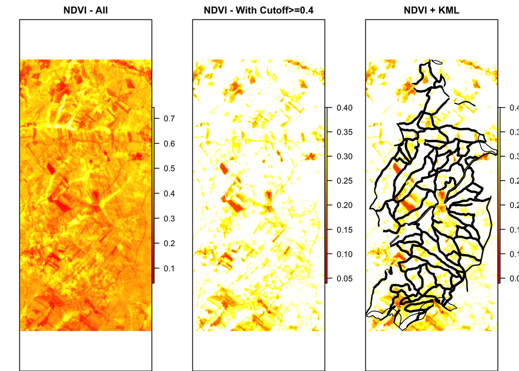

```r
ndvi<-(band8sen-band4sen)/(band8sen+band4sen)
ndvi_reduced<-ndvi
ndvi_reduced[ndvi_reduced>0.4]<-NA
par(mar=c(0,2,2,0), mfrow=c(1,3))
plot(ndvi, axes=FALSE, main="NDVI - All",col=heat.colors(100))
plot(ndvi_reduced, axes=FALSE, main="NDVI - With Cutoff>=0.4",col=heat.colors(100))
plot(ndvi_reduced, axes=FALSE, main="NDVI + KML",col=heat.colors(100))
plot(ds, add=TRUE)
```

#### SAVI

Soil Adjusted Vegetation Index: It’s the same as NDVI, although the difference is the use of a brightness factor **L**, this factor helps to treat all types of soil (some are more reflective than others) the same:

$$SAVI=(\frac{NIR-Red}{NIR+Red+L})*(1+L)$$

The following are plots based on SAVI with brightness factor L=0.5 (default value) and cutoff at 0.4 or above:

Note: Brightness factor is betweem 0 and 1, where 0 is applid for areas with a lot vegetation, effectivly rendering SAVI as NDVI. And 1 where it’s a desert with no vegetation.

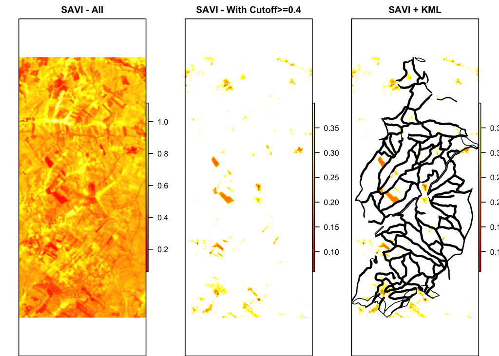

```r
savi<-((band8sen-band4sen)/(band8sen+band4sen+0.5))*(1+0.5)
savi_reduced<-savi
savi_reduced[savi_reduced>0.4]<-NA
par(mar=c(0,2,2,0), mfrow=c(1,3))
plot(savi, axes=FALSE, main="SAVI - All",col=heat.colors(100))
plot(savi_reduced, axes=FALSE, main="SAVI - With Cutoff>=0.4",col=heat.colors(100))
plot(savi_reduced, axes=FALSE, main="SAVI + KML",col=heat.colors(100))
plot(ds, add=TRUE)
```

#### MSAVI2

An improved SAVI that gets rid of the need to identify a brightness factor **L**, therefore avoiding the need to guess the appropriate brightness factor **L**.

Note: the brightness factor **L** is the gradient of the soil line, for more information click [here](https://wiki.landscapetoolbox.org/doku.php/remote_sensing_methods:modified_soil-adjusted_vegetation_index):

$$MSAVI=\frac{(2*NIR+1-\sqrt{(2*NIR+1)^2-8*(NIR-Red)})}{2}$$

The following are plots based on MSAVI2, and cutoff at 0.4 or above:

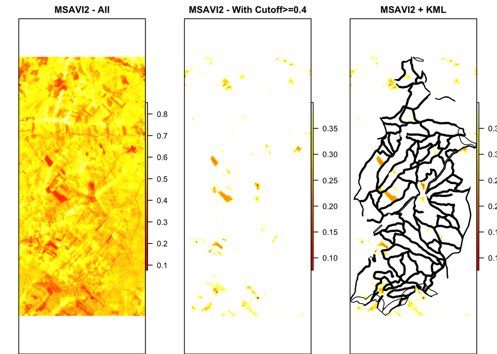

```r
msavi2<-(2*band8sen+1-sqrt((2*band8sen+1)^2-8*(band8sen-band4sen)))/2
msavi2_reduced<-msavi2
msavi2_reduced[msavi2_reduced>0.4]<-NA
par(mar=c(0,2,2,0), mfrow=c(1,3))
plot(msavi2, axes=FALSE, main="MSAVI2 - All",col=heat.colors(100))
plot(msavi2_reduced, axes=FALSE, main="MSAVI2 - With Cutoff>=0.4",col=heat.colors(100))
plot(msavi2_reduced, axes=FALSE, main="MSAVI2 + KML",col=heat.colors(100))
plot(ds, add=TRUE)
```

#### NDBaI

Normalised Difference Barenes Index, is used to identify “bare soil”, amongst other “bare soil” indices. With reference to Landsat7 ETM+ [bands](https://eos.com/landsat-7/), NDBaI can be calculated [as follows](https://www.researchgate.net/post/Can_someone_help_me_in_calculating_NDBaIBareness_Indexusing_LANDSAT_8_data):

*Note:* Band6 of Landsat has 2 files: 6.1 and 6.2, [which are low and high gain settings](https://www.researchgate.net/post/Which_bands_of_Landsat_7_61_or_62_or_both_8_10_or_11_or_both_for_LST_estimation), respectively. Usually the high gain is used for areas with more vegetation, as the thermal reflection will be less, therefore more gain is needed to amplify the signal. Whilst low gain is used for areas like desert, where thermal reflection is high. In our case, we’re going to use the 6.2 (i.e high gain)

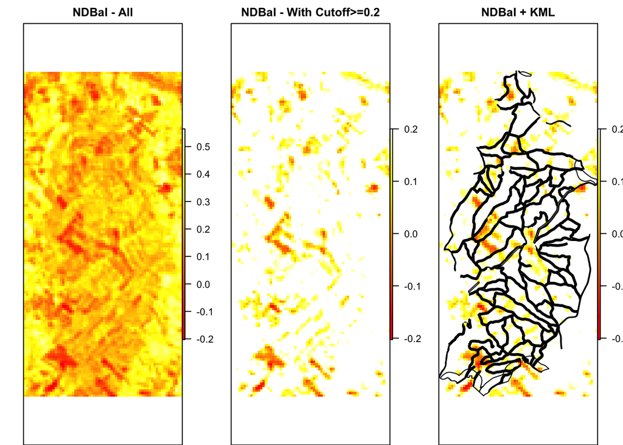

```r
#Load tiff into raster object (bands 5 & 6)
band5lansat7<-raster("Landsat 7/LE07_L1TP_204032_20190528_20190623_01_T1/LE07_L1TP_204032_20190528_20190623_01_T1_B6_VCID_2.TIF")
band6lansat7<-raster("Landsat 7/LE07_L1TP_204032_20190528_20190623_01_T1/LE07_L1TP_204032_20190528_20190623_01_T1_B5.TIF")

#Crop images
band5lansat7<-crop(band5lansat7, extent(ds))
band6lansat7<-crop(band6lansat7, extent(ds))

#Calculate NDBaI
ndbai<-(band5lansat7-band6lansat7)/(band5lansat7+band6lansat7)

#Now plot
ndbai_reduced<-ndbai
ndbai_reduced[ndbai_reduced>0.2]<-NA
par(mar=c(0,2,2,0), mfrow=c(1,3))
plot(ndbai, axes=FALSE, main="NDBaI - All",col=heat.colors(100))
plot(ndbai_reduced, axes=FALSE, main="NDBaI - With Cutoff>=0.2",col=heat.colors(100))
plot(ndbai_reduced, axes=FALSE, main="NDBaI + KML",col=heat.colors(100))
plot(ds, add=TRUE)
```

It can be noted that resolution of Landsat7 (30m), is less than Sentinel 2 (10m).

#### MSAVI2 Custom/Mistake

Basically the same MSAVI2, but I changed the “-” into “+” just before the square root, and it produced interesting results that I thought I can share here:

$$MSAVI=\frac{(2*NIR+1+\sqrt{(2*NIR+1)^2-8*(NIR-Red)})}{2}$$
Plots with cutoff at 5500:

[figure not shown]

```r
msavi2cust<-(2*band8sen+1+sqrt((2*band8sen+1)^2-8*(band8sen-band4sen)))/2
msavi2cust_reduced<-msavi2cust
msavi2cust_reduced[msavi2cust_reduced<5500]<-NA
par(mar=c(0,2,2,0), mfrow=c(1,3))
plot(msavi2cust, axes=FALSE, main="MSAVI2 Custom - All",col=heat.colors(100))
plot(msavi2cust_reduced, axes=FALSE, main="MSAVI2 Custom- With Cutoff>=0.4",col=heat.colors(100))
plot(msavi2cust_reduced, axes=FALSE, main="MSAVI2 Custom + KML",col=heat.colors(100))
plot(ds, add=TRUE)
```

### Statistical Analysis

For a statisitical analysis, it is best described in [this work](http://rpubs.com/omarmn/dsfdsj)